# TrabajoPractivo1

UTN_MinDatos_AIDD_sebacastillo

10/3/2022

```r
multieda <- function(list, df = 1){

  lista_resultados <- list()

  # CV = proporcion que representa el desvıo estandar de la media aritmetica
  lista_resultados$coeficiente_variacion <- list[[df]] %>%
    dplyr::select_if(is.numeric) %>%
    summarise_all(raster::cv, na.rm =T)

  lista_resultados$sesgo <- list[[df]] %>%
    dplyr::select_if(is.numeric) %>%
    summarise_all(moments::skewness)

  # Las distribuciones leptocurticas tienen coeficientes superiores a 3 y las
  # platicurticas coeficientes menores a 3

  lista_resultados$curtosis <- list[[df]] %>%
    dplyr::select_if(is.numeric) %>%
    summarise_all(moments::kurtosis)

  # Estadística Robusta

  # Median Absolute Deviation= mediana de los desvıos absolutos respecto de la mediana
  lista_resultados$mad <- list[[df]] %>%
    dplyr::select_if(is.numeric) %>%
    summarise_all(mad)

  # grafico de correlacion
  lista_resultados$m_correlacion <- list[[df]] %>%
    select_if(is.numeric) %>%
    cor(., use="complete.obs") %>%
    round(., 2)

  lista_resultados
}
```

# Trabajo práctico 1

```r
dataset = 4
results = multieda(df, dataset)
```

## Análisis data set: recepcionistas

### Resumen

```r
knit_print(skim(df[[dataset]]))
```

Data summary

| Name | df[[dataset]] |
| --- | --- |
| Number of rows | 6 |
| Number of columns | 7 |
| _______________________ |  |
| Column type frequency: |  |
| character | 1 |
| numeric | 6 |
| ________________________ |  |
| Group variables | None |

**Variable type: character**

| skim_variable | n_missing | complete_rate | min | max | empty | n_unique | whitespace |
| --- | --- | --- | --- | --- | --- | --- | --- |
| candidatos | 0 | 1 | 4 | 9 | 0 | 6 | 0 |

**Variable type: numeric**

| skim_variable | n_missing | complete_rate | mean | sd | p0 | p25 | p50 | p75 | p100 | hist |
| --- | --- | --- | --- | --- | --- | --- | --- | --- | --- | --- |
| cord.juez 1 | 0 | 1 | 81.67 | 7.53 | 70 | 80.00 | 80.0 | 87.50 | 90 | ▂▁▇▁▅ |
| pres.juez1 | 0 | 1 | 72.50 | 17.82 | 50 | 60.00 | 72.5 | 88.75 | 90 | ▂▅▁▁▇ |
| idiom.juez1 | 0 | 1 | 56.67 | 8.16 | 50 | 50.00 | 55.0 | 60.00 | 70 | ▇▁▅▁▂ |
| cord.juez 2 | 0 | 1 | 66.67 | 8.76 | 55 | 61.25 | 67.5 | 70.00 | 80 | ▇▃▇▁▃ |
| pres.juez2 | 0 | 1 | 74.33 | 14.11 | 58 | 62.50 | 74.0 | 87.00 | 90 | ▇▃▁▃▇ |
| idiom.juez2 | 0 | 1 | 56.67 | 16.02 | 40 | 42.50 | 57.5 | 65.00 | 80 | ▇▃▁▇▃ |

### Distribución de datos

```r
knit_print(results)
```

```
## $coeficiente_variacion
## # A tibble: 1 x 6
##   `cord.juez 1` pres.juez1 idiom.juez1 `cord.juez 2` pres.juez2 idiom.juez2
##           <dbl>      <dbl>       <dbl>         <dbl>      <dbl>       <dbl>
## 1          9.22       24.6        14.4          13.1       19.0        28.3
##
## $sesgo
## # A tibble: 1 x 6
##   `cord.juez 1` pres.juez1 idiom.juez1 `cord.juez 2` pres.juez2 idiom.juez2
##           <dbl>      <dbl>       <dbl>         <dbl>      <dbl>       <dbl>
## 1        -0.228     -0.102       0.626         0.181     0.0278       0.229
##
## $curtosis
## # A tibble: 1 x 6
##   `cord.juez 1` pres.juez1 idiom.juez1 `cord.juez 2` pres.juez2 idiom.juez2
##           <dbl>      <dbl>       <dbl>         <dbl>      <dbl>       <dbl>
## 1          2.11       1.23        2.04          2.14       1.42        1.68
##
## $mad
## # A tibble: 1 x 6
##   `cord.juez 1` pres.juez1 idiom.juez1 `cord.juez 2` pres.juez2 idiom.juez2
##           <dbl>      <dbl>       <dbl>         <dbl>      <dbl>       <dbl>
## 1          7.41       22.2        7.41          7.41       22.2        18.5
##
## $m_correlacion
##             cord.juez 1 pres.juez1 idiom.juez1 cord.juez 2 pres.juez2
## cord.juez 1        1.00       0.19        0.11        0.86       0.11
## pres.juez1         0.19       1.00        0.89        0.06       0.90
## idiom.juez1        0.11       0.89        1.00       -0.05       0.67
## cord.juez 2        0.86       0.06       -0.05        1.00       0.17
## pres.juez2         0.11       0.90        0.67        0.17       1.00
## idiom.juez2       -0.53       0.49        0.59       -0.81       0.25
##             idiom.juez2
## cord.juez 1       -0.53
## pres.juez1         0.49
## idiom.juez1        0.59
## cord.juez 2       -0.81
## pres.juez2         0.25
## idiom.juez2        1.00
```

### Explorarcion de interrogantes

```r
datos = df[[dataset]]
columnas = names(datos)[-1]

datos <- datos %>%
  pivot_longer(cols = columnas, names_to = 'variables', values_to = 'valores') %>%
  mutate(variables = str_remove_all(variables, ' ')) %>%
  separate(col = variables, into = c('variables', 'juez'), sep = '\\.')
```

#### Ranking por candidatos por juez: no existe coincidencia en el primer puesto.

```r
datos %>% group_by(juez, candidatos) %>% summarise(promedio = round(mean(valores), digits = 2)) %>%
  arrange(juez, desc(promedio)) %>%
  kable()
```

| juez | candidatos | promedio |
| --- | --- | --- |
| juez1 | Mariana | 80.00 |
| juez1 | Carla | 78.33 |
| juez1 | Maia | 76.67 |
| juez1 | Sabrina | 66.67 |
| juez1 | Alejandra | 60.00 |
| juez1 | Daniela | 60.00 |
| juez2 | Maia | 73.33 |
| juez2 | Mariana | 72.67 |
| juez2 | Carla | 70.00 |
| juez2 | Alejandra | 63.33 |
| juez2 | Sabrina | 60.00 |
| juez2 | Daniela | 56.00 |

#### Promedio de cada una de las aspirantes tomando en cuenta todos los rubros y ambos jueces

```r
datos %>% group_by(candidatos) %>% summarise(promedio = round(mean(valores), digits = 2)) %>%
  arrange(desc(promedio)) %>%
  kable()
```

| candidatos | promedio |
| --- | --- |
| Mariana | 76.33 |
| Maia | 75.00 |
| Carla | 74.17 |
| Sabrina | 63.33 |
| Alejandra | 61.67 |
| Daniela | 58.00 |

#### Transformar las puntuaciones

Vamos a centrar los valores para evitar el sesgo de los jueces al momento de la asignación de puntajes. Esto permitirá centrar los valores (promedio en 0 y sd en 1) con el fin de permitir su comparación. Luego vamos a sumar los valores obtenidos por cada candidata.

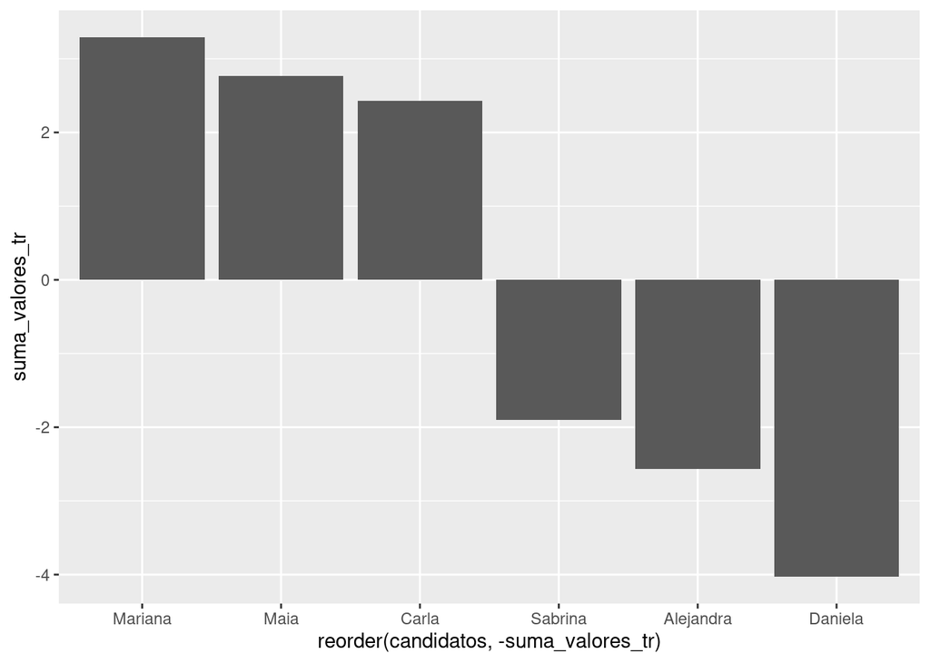

```r
datos %>%
  mutate(valores_tr = scale(valores)) %>%
  group_by(candidatos) %>%
  summarise(suma_valores_tr = sum(valores_tr, na.rm = T)) %>%
  arrange(desc(suma_valores_tr)) %>%
  ggplot(aes(x= reorder(candidatos, -suma_valores_tr), y = suma_valores_tr)) +
  geom_bar(stat = 'identity')
```

# Exploración para profundizar aprendizaje

```r
# otros estadìsticos
datos_matriz <- datos %>%
  pivot_wider(names_from = variables, values_from = valores) #%>%
  #mutate(juez = as.integer(str_remove_all(juez, '[a-z]')))

# Depende de las unidades en que se miden las variables
matriz_varianza <- datos_matriz %>%
  select_if(is.numeric) %>%
  var(., use="complete.obs") %>%
  round(., 2)

matriz_covarianza <- datos_matriz %>%
  select_if(is.numeric) %>%
  cov(., use="complete.obs") %>%
  round(., 2)

# correlacion: covarianza de los datos estandarizados
matriz_correlacion <- datos_matriz %>%
  select_if(is.numeric) %>%
  cor(., use="complete.obs") %>%
  round(., 2)


determinante <- det(matriz_covarianza)

# traza = sum(diagonal matriz cuadrada). En el caso de la matriz de var-covar
# la traza daría por resultado la suma de las varianzas y por lo tanto una idea
# de la magnitud del problema a explicar
```

```r
datos_matriz
```

| candidatos | juez | cord | pres | idiom |
| --- | --- | --- | --- | --- |
| Mariana | juez1 | 80 | 90 | 70 |
| Mariana | juez2 | 60 | 78 | 80 |
| Maia | juez1 | 80 | 90 | 60 |
| Maia | juez2 | 65 | 90 | 65 |
| Sabrina | juez1 | 90 | 60 | 50 |
| Sabrina | juez2 | 70 | 60 | 50 |
| Daniela | juez1 | 80 | 50 | 50 |
| Daniela | juez2 | 70 | 58 | 40 |
| Alejandra | juez1 | 70 | 60 | 50 |
| Alejandra | juez2 | 55 | 70 | 65 |

[output cut: 2 more lines]

```r
matriz_varianza
```

```
##         cord   pres  idiom
## cord  121.97  13.56 -48.48
## pres   13.56 235.72  85.15
## idiom -48.48  85.15 146.97
```

```r
matriz_covarianza
```

```
##         cord   pres  idiom
## cord  121.97  13.56 -48.48
## pres   13.56 235.72  85.15
## idiom -48.48  85.15 146.97
```

```r
matriz_correlacion
```

```
##        cord pres idiom
## cord   1.00 0.08 -0.36
## pres   0.08 1.00  0.46
## idiom -0.36 0.46  1.00
```

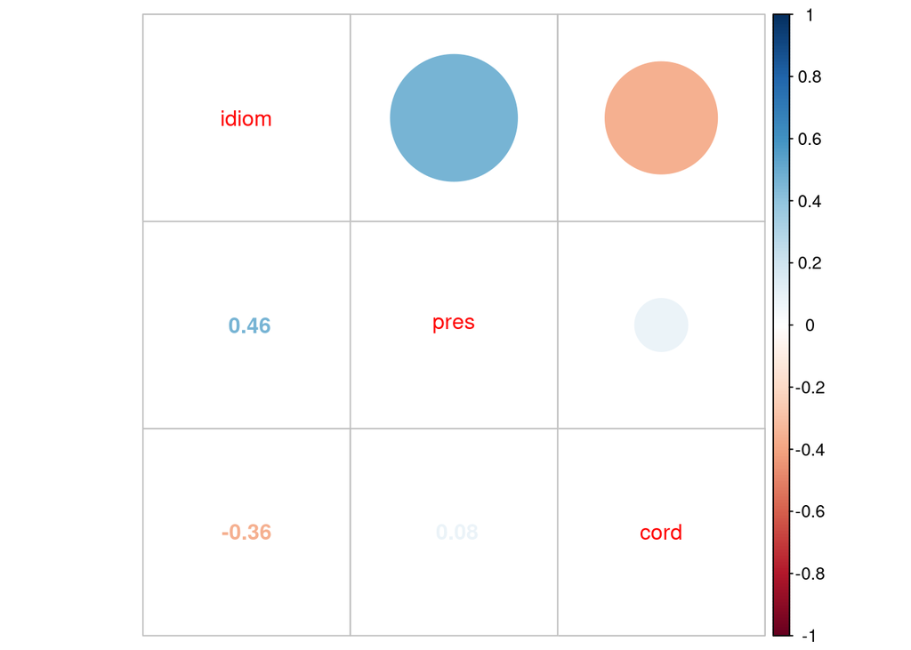

```r
corrplot::corrplot.mixed(matriz_correlacion ,order = 'AOE')
```

# Determinante distinto de 0 => independencia lineal

```r
determinante
```

```
## [1] 2648162
```

# Revisión de los analíticos estudiados

Atención que la función ‘var’ en R calcula la varianza teniendo como divisor ‘n-1’, que no coincide con las formulas de Peña.

```r
round(var(datos_matriz$cord), digits = 2) ==
  round(sum((datos_matriz$cord - mean(datos_matriz$cord))^2) /
          (length(datos_matriz$cord)-1), digits = 2) # este -1 es muy importante
```

```
## [1] TRUE
```

# desviación estandar

```r
round(sd(datos_matriz$cord), digits = 2)
```

```
## [1] 11.04
```

```r
sqrt(round(sum((datos_matriz$cord - mean(datos_matriz$cord))^2) /
          (length(datos_matriz$cord)-1), digits = 2))
```

```
## [1] 11.044
```

# varianza

var() = el cuadrado de la sd()

```r
sqrt(round(sum((datos_matriz$cord - mean(datos_matriz$cord))^2) /
          (length(datos_matriz$cord)-1), digits = 2))^2 # el cuadrado de la desviación típica
```

```
## [1] 121.97
```

# Covarianza

```r
sum((datos_matriz$cord - mean(datos_matriz$cord)) * (datos_matriz$pres - mean(datos_matriz$pres))) / (length(datos_matriz$cord)-1)
```

```
## [1] 13.56061
```

# Distribuciones

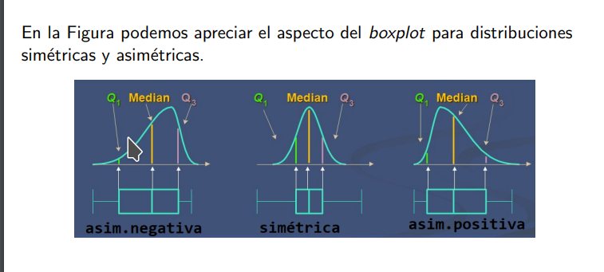

```r
include_graphics('distribuciones.png')
```

```r
dataset = 1
results = multieda(df, dataset)
```

## Análisis data set: IMCinfantil

### Resumen

```r
knit_print(skim(df[[dataset]]))
```

Data summary

| Name | df[[dataset]] |
| --- | --- |
| Number of rows | 150 |
| Number of columns | 9 |
| _______________________ |  |
| Column type frequency: |  |
| character | 2 |
| numeric | 7 |
| ________________________ |  |
| Group variables | None |

**Variable type: character**

| skim_variable | n_missing | complete_rate | min | max | empty | n_unique | whitespace |
| --- | --- | --- | --- | --- | --- | --- | --- |
| SEXO | 0 | 1 | 1 | 1 | 0 | 2 | 0 |
| CatPeso | 0 | 1 | 1 | 2 | 0 | 4 | 0 |

**Variable type: numeric**

| skim_variable | n_missing | complete_rate | mean | sd | p0 | p25 | p50 | p75 | p100 | hist |
| --- | --- | --- | --- | --- | --- | --- | --- | --- | --- | --- |
| PACIENTE | 0 | 1 | 75.50 | 43.45 | 1.00 | 38.25 | 75.50 | 112.75 | 150.00 | ▇▇▇▇▇ |
| EDAD | 0 | 1 | 8.33 | 1.63 | 6.00 | 7.00 | 8.00 | 9.00 | 12.00 | ▇▆▅▃▃ |
| PESO | 0 | 1 | 33.40 | 11.16 | 18.50 | 23.92 | 31.45 | 40.00 | 80.80 | ▇▆▂▁▁ |
| TALLA | 0 | 1 | 1.32 | 0.12 | 1.10 | 1.20 | 1.30 | 1.40 | 1.70 | ▇▇▅▂▁ |
| IMC | 0 | 1 | 18.60 | 3.39 | 13.26 | 16.27 | 17.77 | 20.86 | 31.56 | ▇▇▅▁▁ |
| PIMC | 0 | 1 | 68.56 | 28.57 | 2.02 | 53.02 | 79.75 | 91.23 | 99.27 | ▂▂▂▃▇ |
| CC | 0 | 1 | 65.25 | 10.74 | 50.00 | 56.25 | 63.00 | 72.75 | 107.00 | ▇▅▃▁▁ |

### Distribución de datos

```r
knit_print(results)
```

```
## $coeficiente_variacion
## # A tibble: 1 x 7
##   PACIENTE  EDAD  PESO TALLA   IMC  PIMC    CC
##      <dbl> <dbl> <dbl> <dbl> <dbl> <dbl> <dbl>
## 1     57.5  19.6  33.4  9.36  18.2  41.7  16.5
##
## $sesgo
## # A tibble: 1 x 7
##   PACIENTE  EDAD  PESO TALLA   IMC   PIMC    CC
##      <dbl> <dbl> <dbl> <dbl> <dbl>  <dbl> <dbl>
## 1        0 0.391  1.05 0.621 0.908 -0.947 0.737
##
## $curtosis
## # A tibble: 1 x 7
##   PACIENTE  EDAD  PESO TALLA   IMC  PIMC    CC
##      <dbl> <dbl> <dbl> <dbl> <dbl> <dbl> <dbl>
## 1     1.80  2.34  4.19  2.91  3.64  2.71  3.25
##
## $mad
## # A tibble: 1 x 7
##   PACIENTE  EDAD  PESO TALLA   IMC  PIMC    CC
##      <dbl> <dbl> <dbl> <dbl> <dbl> <dbl> <dbl>
## 1     55.6  1.48  11.5 0.148  3.14  23.2  10.4
##
## $m_correlacion
##          PACIENTE EDAD  PESO TALLA  IMC  PIMC   CC
## PACIENTE     1.00 0.02 -0.02 -0.05 0.00 -0.02 0.05
## EDAD         0.02 1.00  0.73  0.84 0.45  0.14 0.64
## PESO        -0.02 0.73  1.00  0.87 0.87  0.60 0.92
## TALLA       -0.05 0.84  0.87  1.00 0.54  0.34 0.73
## IMC          0.00 0.45  0.87  0.54 1.00  0.76 0.88
## PIMC        -0.02 0.14  0.60  0.34 0.76  1.00 0.63
## CC           0.05 0.64  0.92  0.73 0.88  0.63 1.00
```

### Gràfico de correlacion

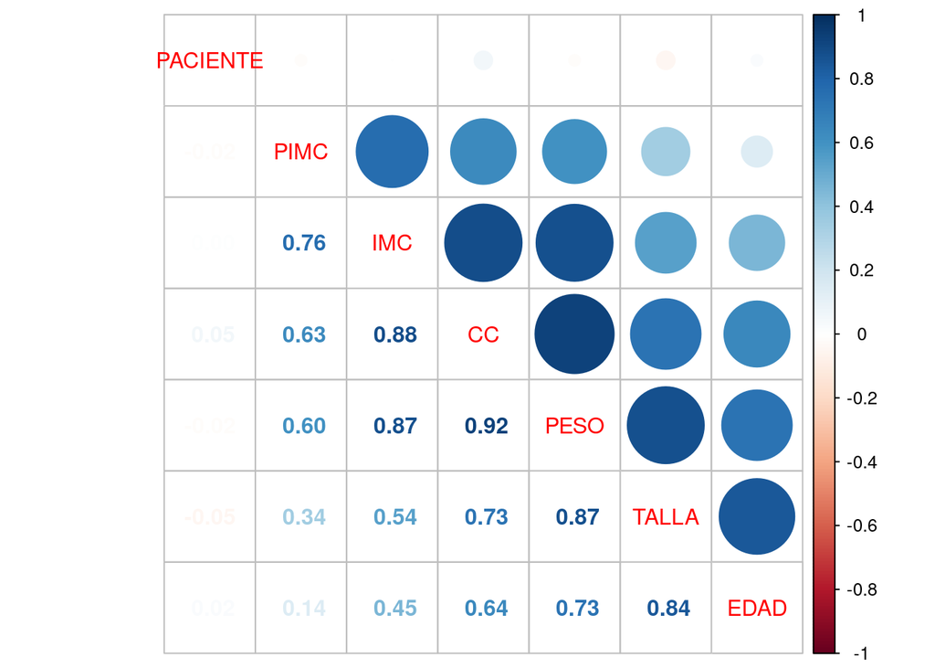

```r
corrplot::corrplot.mixed(results$m_correlacion ,order = 'AOE')
```

# Distancia de Mahalanobis

Es efectiva en datos multivariados pues utiliza la covarianza entre variables para medir la distancia entre dos observaciones.

Aquí hemos agregado la distancia de mahalanobis y hemos detectado outliers por su valor p. Fltramos el dataframe por la filas cuya probabilidad sean menores a 0.001.

```r
# Distancia de Mahalanobis
  temp <- df[[dataset]] %>%
    dplyr::select_if(is.numeric)

  temp$mahalanobis <- mahalanobis(temp, colMeans(temp), cov(temp))

  temp$pvalue <- pchisq(temp$mahalanobis, df =7, lower.tail=FALSE)

  temp$outlier <- temp$pvalue < 0.001

  temp[temp$outlier, ]
```

| PACIENTE | EDAD | PESO | TALLA | IMC | PIMC | CC | mahalanobis | pvalue | outlier |
| --- | --- | --- | --- | --- | --- | --- | --- | --- | --- |
| 16 | 11 | 25.5 | 1.3 | 15.08876 | 2.07 | 73 | 33.34368 | 2.284483e-05 | TRUE |
| 51 | 11 | 80.8 | 1.6 | 31.56250 | 99.27 | 107 | 62.66510 | 4.423406e-11 | TRUE |

Graficamos las distancias de Mahalanobis y vemos outliers. Se destacan más datos que por valor p.

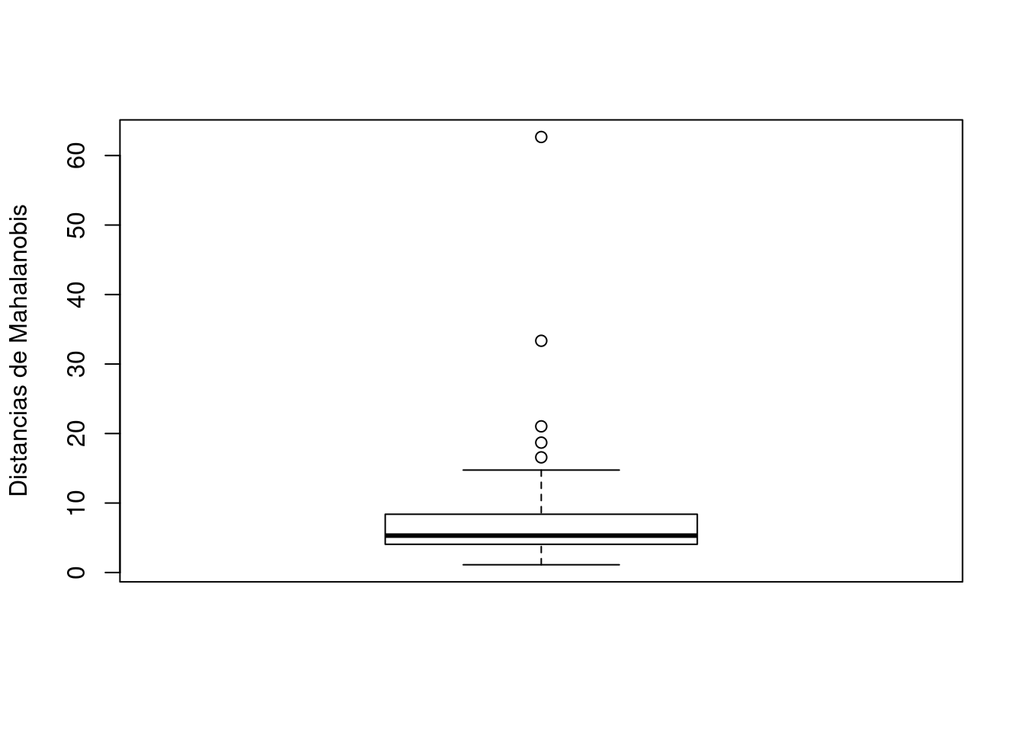

```r
boxplot(temp$mahalanobis, ylab = "Distancias de Mahalanobis")
```

```r
dataset = 2
results = multieda(df, dataset)
```

## Análisis data set: gorriones

### Resumen

```r
knit_print(skim(df[[dataset]]))
```

Data summary

| Name | df[[dataset]] |
| --- | --- |
| Number of rows | 49 |
| Number of columns | 7 |
| _______________________ |  |
| Column type frequency: |  |
| numeric | 7 |
| ________________________ |  |
| Group variables | None |

**Variable type: numeric**

| skim_variable | n_missing | complete_rate | mean | sd | p0 | p25 | p50 | p75 | p100 | hist |
| --- | --- | --- | --- | --- | --- | --- | --- | --- | --- | --- |
| Pájaro | 0 | 1 | 25.00 | 14.29 | 1.0 | 13.0 | 25.0 | 37.0 | 49.0 | ▇▇▇▇▇ |
| Largo total | 0 | 1 | 157.98 | 3.65 | 152.0 | 155.0 | 158.0 | 161.0 | 165.0 | ▃▇▃▅▃ |
| Extensión alar | 0 | 1 | 241.33 | 5.07 | 230.0 | 238.0 | 242.0 | 245.0 | 252.0 | ▂▇▇▇▃ |
| Largo del pico y cabeza | 0 | 1 | 31.46 | 0.79 | 30.1 | 30.9 | 31.5 | 32.0 | 33.4 | ▅▇▇▅▂ |
| Largo del húmero | 0 | 1 | 18.45 | 0.54 | 17.2 | 18.1 | 18.5 | 18.8 | 19.8 | ▂▆▇▅▂ |
| Largo de la quilla del esternón | 0 | 1 | 20.83 | 0.99 | 18.6 | 20.2 | 20.7 | 21.5 | 23.1 | ▂▇▇▅▂ |
| Sobrevida vivo= 1, muerto= -1 | 0 | 1 | -0.14 | 1.00 | -1.0 | -1.0 | -1.0 | 1.0 | 1.0 | ▇▁▁▁▆ |

### Distribución de datos

```r
knit_print(results)
```

```
## $coeficiente_variacion
## # A tibble: 1 x 7
##   Pájaro `Largo total` `Extensión alar` `Largo del pico y cab… `Largo del húmer…
##    <dbl>         <dbl>            <dbl>                  <dbl>             <dbl>
## 1   57.2          2.31             2.10                   2.53              2.95
## # … with 2 more variables: Largo de la quilla del esternón <dbl>,
## #   Sobrevida vivo= 1, muerto= -1 <dbl>
##
## $sesgo
## # A tibble: 1 x 7
##   Pájaro `Largo total` `Extensión alar` `Largo del pico y cab… `Largo del húmer…
##    <dbl>         <dbl>            <dbl>                  <dbl>             <dbl>
## 1      0         0.148           -0.130                  0.381           -0.0885
## # … with 2 more variables: Largo de la quilla del esternón <dbl>,
## #   Sobrevida vivo= 1, muerto= -1 <dbl>
##
## $curtosis
## # A tibble: 1 x 7
##   Pájaro `Largo total` `Extensión alar` `Largo del pico y cab… `Largo del húmer…
##    <dbl>         <dbl>            <dbl>                  <dbl>             <dbl>
## 1   1.80          1.87             2.41                   2.49              3.18
## # … with 2 more variables: Largo de la quilla del esternón <dbl>,
## #   Sobrevida vivo= 1, muerto= -1 <dbl>
##
## $mad
## # A tibble: 1 x 7
##   Pájaro `Largo total` `Extensión alar` `Largo del pico y cab… `Largo del húmer…
##    <dbl>         <dbl>            <dbl>                  <dbl>             <dbl>
## 1   17.8          4.45             5.93                  0.890             0.445
## # … with 2 more variables: Largo de la quilla del esternón <dbl>,
## #   Sobrevida vivo= 1, muerto= -1 <dbl>
##
## $m_correlacion
##                                 Pájaro Largo total Extensión alar
## Pájaro                            1.00        0.25           0.07
## Largo total                       0.25        1.00           0.73
## Extensión alar                    0.07        0.73           1.00
## Largo del pico y cabeza           0.06        0.66           0.67
## Largo del húmero                 -0.01        0.68           0.77
## Largo de la quilla del esternón  -0.02        0.61           0.53
```

[output cut: 10 more lines]

```
## Pájaro                                                    -0.02
## Largo total                                                0.61
## Extensión alar                                             0.53
## Largo del pico y cabeza                                    0.53
## Largo del húmero                                           0.61
## Largo de la quilla del esternón                            1.00
## Sobrevida vivo= 1, muerto= -1                             -0.02
##                                 Sobrevida vivo= 1, muerto= -1
## Pájaro                                                  -0.86
## Largo total                                             -0.14
## Extensión alar                                          -0.06
## Largo del pico y cabeza                                 -0.03
## Largo del húmero                                         0.08
## Largo de la quilla del esternón                         -0.02
## Sobrevida vivo= 1, muerto= -1                            1.00
```

### Gràfico de correlacion

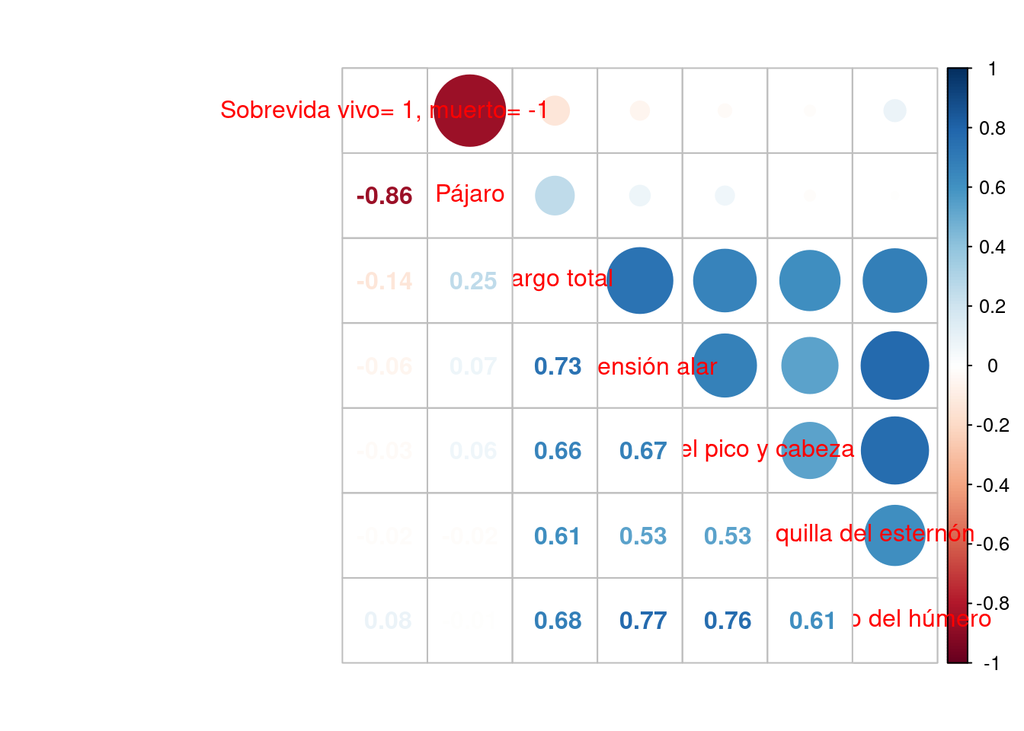

```r
corrplot::corrplot.mixed(results$m_correlacion ,order = 'AOE')
```

```r
dataset = 3
results = multieda(df, dataset)
```

## Análisis data set: Internet2013

### Resumen

```r
knit_print(skim(df[[dataset]]))
```

Data summary

| Name | df[[dataset]] |
| --- | --- |
| Number of rows | 1500 |
| Number of columns | 10 |
| _______________________ |  |
| Column type frequency: |  |
| character | 1 |
| numeric | 9 |
| ________________________ |  |
| Group variables | None |

**Variable type: character**

| skim_variable | n_missing | complete_rate | min | max | empty | n_unique | whitespace |
| --- | --- | --- | --- | --- | --- | --- | --- |
| Nacionalidad | 0 | 1 | 6 | 9 | 0 | 4 | 0 |

**Variable type: numeric**

| skim_variable | n_missing | complete_rate | mean | sd | p0 | p25 | p50 | p75 | p100 | hist |
| --- | --- | --- | --- | --- | --- | --- | --- | --- | --- | --- |
| ID | 0 | 1 | 750.50 | 433.16 | 1.00 | 375.75 | 750.50 | 1125.25 | 1500.00 | ▇▇▇▇▇ |
| Edad | 0 | 1 | 36.18 | 15.77 | -44.00 | 24.00 | 35.00 | 48.00 | 280.00 | ▂▇▁▁▁ |
| Sexo | 0 | 1 | 1.54 | 0.50 | 0.00 | 1.00 | 2.00 | 2.00 | 2.00 | ▁▁▇▁▇ |
| Estatura | 0 | 1 | 1.67 | 0.08 | 1.47 | 1.61 | 1.66 | 1.71 | 1.93 | ▂▇▇▂▁ |
| Sitio | 0 | 1 | 4.49 | 2.13 | 1.00 | 2.00 | 5.00 | 7.00 | 28.00 | ▇▃▁▁▁ |
| Uso | 0 | 1 | 110.35 | 77.20 | -10.00 | 47.00 | 97.00 | 152.00 | 350.00 | ▇▇▃▂▁ |
| Temperatura | 0 | 1 | 10.97 | 10.70 | -14.00 | 5.00 | 11.00 | 18.00 | 131.00 | ▇▅▁▁▁ |
| Autos | 0 | 1 | 100.94 | 87.21 | 0.00 | 49.00 | 99.50 | 147.00 | 2680.00 | ▇▁▁▁▁ |
| Cigarrillos | 0 | 1 | 3.05 | 5.08 | 0.00 | 0.00 | 2.00 | 4.00 | 100.00 | ▇▁▁▁▁ |

### Distribución de datos

```r
knit_print(results)
```

```
## $coeficiente_variacion
## # A tibble: 1 x 9
##      ID  Edad  Sexo Estatura Sitio   Uso Temperatura Autos Cigarrillos
##   <dbl> <dbl> <dbl>    <dbl> <dbl> <dbl>       <dbl> <dbl>       <dbl>
## 1  57.7  43.5  32.4     4.70  47.5  70.0        85.2  86.4        167.
##
## $sesgo
## # A tibble: 1 x 9
##      ID  Edad   Sexo Estatura Sitio   Uso Temperatura Autos Cigarrillos
##   <dbl> <dbl>  <dbl>    <dbl> <dbl> <dbl>       <dbl> <dbl>       <dbl>
## 1     0  3.06 -0.187    0.406 0.723 0.919        1.19  17.3        7.76
##
## $curtosis
## # A tibble: 1 x 9
##      ID  Edad  Sexo Estatura Sitio   Uso Temperatura Autos Cigarrillos
##   <dbl> <dbl> <dbl>    <dbl> <dbl> <dbl>       <dbl> <dbl>       <dbl>
## 1  1.80  45.0  1.08     3.06  11.2  3.20        15.0  511.        120.
##
## $mad
## # A tibble: 1 x 9
##      ID  Edad  Sexo Estatura Sitio   Uso Temperatura Autos Cigarrillos
##   <dbl> <dbl> <dbl>    <dbl> <dbl> <dbl>       <dbl> <dbl>       <dbl>
## 1  556.  17.8     0   0.0741  2.97  75.6        10.4  71.9        2.97
##
## $m_correlacion
##                ID  Edad  Sexo Estatura Sitio   Uso Temperatura Autos
## ID           1.00 -0.01  0.10    -0.10 -0.02 -0.10       -0.02 -0.01
## Edad        -0.01  1.00 -0.01    -0.03  0.54  0.02        0.01 -0.01
## Sexo         0.10 -0.01  1.00    -0.20 -0.06 -0.03       -0.05 -0.02
## Estatura    -0.10 -0.03 -0.20     1.00  0.00  0.00       -0.02 -0.05
## Sitio       -0.02  0.54 -0.06     0.00  1.00  0.02        0.00  0.01
## Uso         -0.10  0.02 -0.03     0.00  0.02  1.00        0.04  0.01
## Temperatura -0.02  0.01 -0.05    -0.02  0.00  0.04        1.00  0.01
## Autos       -0.01 -0.01 -0.02    -0.05  0.01  0.01        0.01  1.00
## Cigarrillos  0.01  0.09  0.05    -0.03  0.04  0.26        0.10 -0.03
##             Cigarrillos
## ID                 0.01
## Edad               0.09
## Sexo               0.05
## Estatura          -0.03
## Sitio              0.04
## Uso                0.26
## Temperatura        0.10
## Autos             -0.03
## Cigarrillos        1.00
```

### Gràfico de correlacion

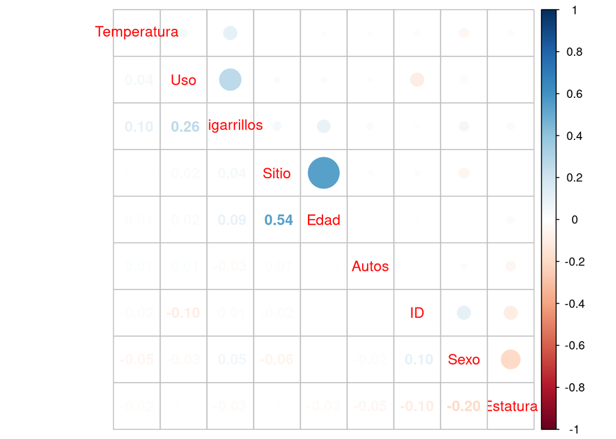

```r
corrplot::corrplot.mixed(results$m_correlacion ,order = 'AOE')
```